# Bənd Diskriminasiya İndeksi: D = pₕ - pₗ

Klassik Test Nəzəriyyəsi - Bənd Diskriminasiya Analizi

Klassik Test Nəzəriyyəsi Kursu

2025-07-17

## 0.1 Dərsin Məqsədləri

✓ Bənd diskriminasiya indeksinin anlayışını və hesablanmasını öyrənmək  
✓ D = pₕ - pₗ formulasını praktik tətbiq etmək  
✓ Biserial və point-biserial korrelyasiya anlayışlarını mənimsəmək  
✓ Müxtəlif diskriminasiya indekslərini müqayisə etmək  
✓ R-da diskriminasiya analizlərini aparmaq

## 0.2 Əvvəlki Dərsdən Xatırladıqlarımız

**Dərs 11-də öyrəndiklərimiz:** - Bənd çətinlik indeksi (p = doğru cavab sayı / ümumi sayı) - Optimal çətinlik səviyyələri (p = 0.30-0.70) - Çətinlik və diskriminasiya arasındakı əlaqə - Test optimallaşdırma strategiyaları

# 1 Diskriminasiya İndeksinin Əsasları

## 1.1 Diskriminasiya Anlayışı və Mahiyyəti

**Bənd diskriminasiya indeksi** - bəndin yüksək qabiliyyətli və aşağı qabiliyyətli şəxsləri ayırd etmə qabiliyyətinin ölçüsüdür.

### 1.1.1 **D = pₕ - pₗ**

Bu formulada: - **D** = Diskriminasiya indeksi (-1.0 ≤ D ≤ +1.0) - **pₕ** = Yüksək qrup üçün çətinlik indeksi  
- **pₗ** = Aşağı qrup üçün çətinlik indeksi

```r
# Diskriminasiya konseptinin vizual izahı
conceptual_example <- data.frame(
  Bənd = paste("Bənd", 1:6),
  Yüksək_Qrup_p = c(0.85, 0.75, 0.90, 0.60, 0.45, 0.30),
  Aşağı_Qrup_p = c(0.25, 0.45, 0.85, 0.55, 0.50, 0.35),
  Diskriminasiya_D = c(0.85, 0.75, 0.90, 0.60, 0.45, 0.30) -
                     c(0.25, 0.45, 0.85, 0.55, 0.50, 0.35),
  Keyfiyyət = c("Əla", "Yaxşı", "Zəif", "Zəif", "Neqativ", "Neqativ")
)

kable(conceptual_example,
      caption = "Diskriminasiya İndeksinin Hesablanması və İnterpretasiyası",
      digits = 2)
```

Diskriminasiya İndeksinin Hesablanması və İnterpretasiyası

| Bənd | Yüksək_Qrup_p | Aşağı_Qrup_p | Diskriminasiya_D | Keyfiyyət |
| --- | --- | --- | --- | --- |
| Bənd 1 | 0.85 | 0.25 | 0.60 | Əla |
| Bənd 2 | 0.75 | 0.45 | 0.30 | Yaxşı |
| Bənd 3 | 0.90 | 0.85 | 0.05 | Zəif |
| Bənd 4 | 0.60 | 0.55 | 0.05 | Zəif |
| Bənd 5 | 0.45 | 0.50 | -0.05 | Neqativ |
| Bənd 6 | 0.30 | 0.35 | -0.05 | Neqativ |

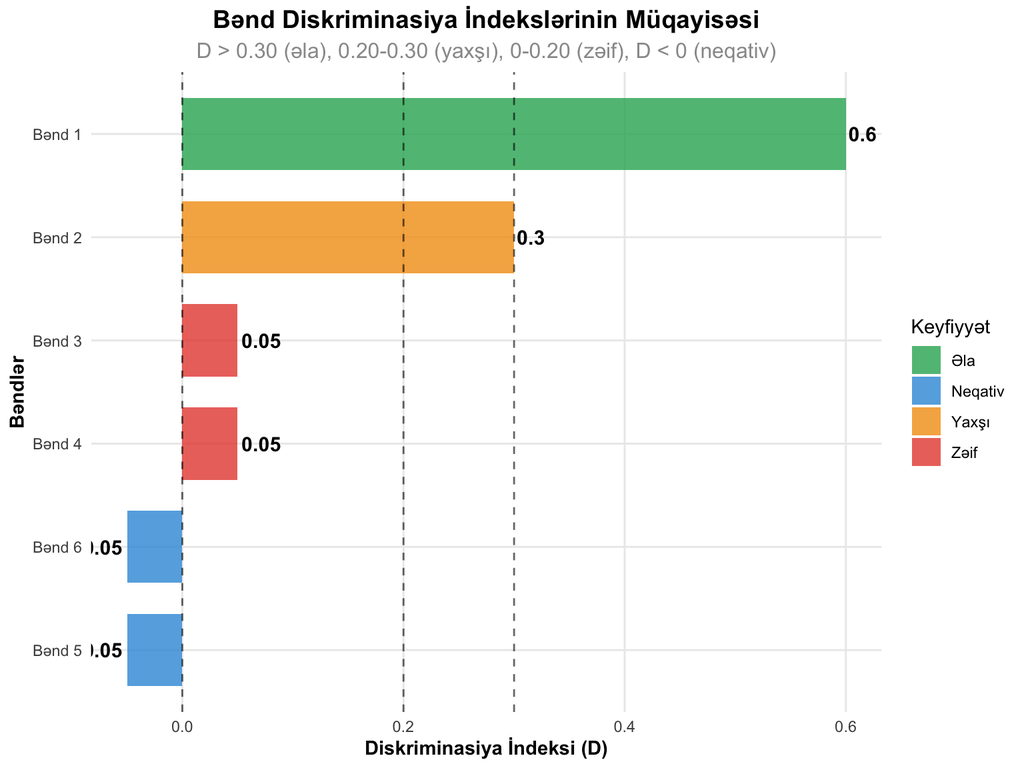

```r
# Diskriminasiya keyfiyyətinin vizuallaşdırılması
ggplot(conceptual_example, aes(x = reorder(Bənd, Diskriminasiya_D),
                               y = Diskriminasiya_D, fill = Keyfiyyət)) +
  geom_col(alpha = 0.8, width = 0.7) +
  geom_text(aes(label = round(Diskriminasiya_D, 2)),
            hjust = ifelse(conceptual_example$Diskriminasiya_D >= 0, -0.1, 1.1),
            fontface = "bold", size = 4) +
  geom_hline(yintercept = c(0, 0.20, 0.30), linetype = "dashed", alpha = 0.6) +
  coord_flip() +
  scale_fill_manual(values = c("Əla" = colors_basic[4], "Yaxşı" = colors_basic[3],
                               "Zəif" = colors_basic[2], "Neqativ" = colors_basic[1])) +
  labs(title = "Bənd Diskriminasiya İndekslərinin Müqayisəsi",
       subtitle = "D > 0.30 (əla), 0.20-0.30 (yaxşı), 0-0.20 (zəif), D < 0 (neqativ)",
       x = "Bəndlər", y = "Diskriminasiya İndeksi (D)", fill = "Keyfiyyət") +
  theme_clean()
```

## 1.2 Diskriminasiya Səviyyələrinin Təsnifatı

```r
# Diskriminasiya indeksinin standart təsnifatı
discrimination_levels <- data.frame(
  D_Aralığı = c("D ≥ 0.40", "0.30 ≤ D < 0.40", "0.20 ≤ D < 0.30",
                "0.00 ≤ D < 0.20", "D < 0.00"),
  Keyfiyyət_Səviyyəsi = c("Çox Yaxşı", "Yaxşı", "Orta", "Zəif", "Neqativ/Problemli"),
  Tövsiyə = c("Saxla", "Saxla", "Yaxşılaşdır", "Ciddi yaxşılaşdır", "Sil və ya yenidən yaz"),
  Tezlik_Faizi = c("5-10%", "15-25%", "30-40%", "20-30%", "0-5%")
)

kable(discrimination_levels, caption = "Diskriminasiya İndekslərinin Standart Təsnifatı")
```

Diskriminasiya İndekslərinin Standart Təsnifatı

| D_Aralığı | Keyfiyyət_Səviyyəsi | Tövsiyə | Tezlik_Faizi |
| --- | --- | --- | --- |
| D ≥ 0.40 | Çox Yaxşı | Saxla | 5-10% |
| 0.30 ≤ D < 0.40 | Yaxşı | Saxla | 15-25% |
| 0.20 ≤ D < 0.30 | Orta | Yaxşılaşdır | 30-40% |
| 0.00 ≤ D < 0.20 | Zəif | Ciddi yaxşılaşdır | 20-30% |
| D < 0.00 | Neqativ/Problemli | Sil və ya yenidən yaz | 0-5% |

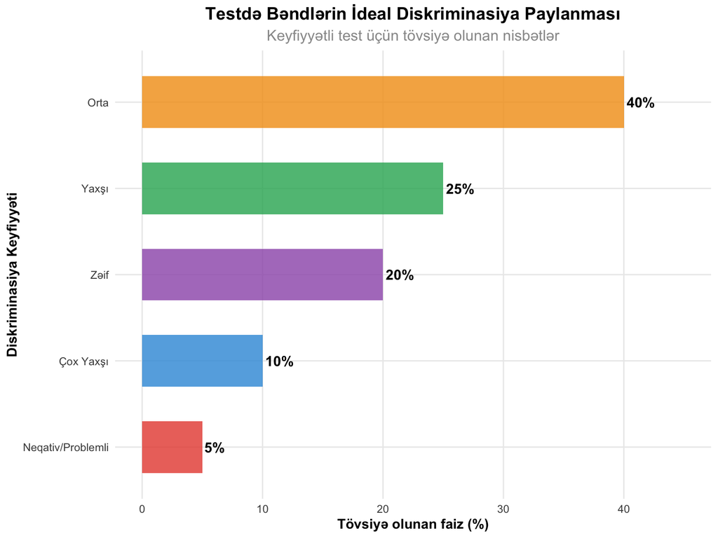

```r
# İdeal diskriminasiya paylanması
ideal_dist <- data.frame(
  Səviyyə = discrimination_levels$Keyfiyyət_Səviyyəsi,
  İdeal_Faiz = c(10, 25, 40, 20, 5),
  Rəng = colors_basic[1:5]
)

ggplot(ideal_dist, aes(x = reorder(Səviyyə, İdeal_Faiz), y = İdeal_Faiz, fill = Səviyyə)) +
  geom_col(alpha = 0.8, width = 0.6) +
  geom_text(aes(label = paste0(İdeal_Faiz, "%")),
            hjust = -0.1, fontface = "bold", size = 4) +
  coord_flip() +
  scale_fill_manual(values = ideal_dist$Rəng) +
  labs(title = "Testdə Bəndlərin İdeal Diskriminasiya Paylanması",
       subtitle = "Keyfiyyətli test üçün tövsiyə olunan nisbətlər",
       x = "Diskriminasiya Keyfiyyəti", y = "Tövsiyə olunan faiz (%)") +
  theme_clean() +
  theme(legend.position = "none") +
  ylim(0, 45)
```

# 2 Diskriminasiya İndeksinin Hesablanması

## 2.1 %27 Metodu (Upper-Lower 27%)

**Standart metodoloji:** Ümumi ballarına görə tələbələrin üst %27-si və alt %27-si seçilir.

```r
# Test məlumatlarının yaradılması
set.seed(123)
n_students <- 100
n_items <- 8

# Müxtəlif diskriminasiya qabiliyyətləri ilə bəndlər
true_discrimination <- c(0.50, 0.35, 0.25, 0.15, 0.05, -0.10, 0.40, 0.30)

# Test cavablarının simulyasiyası
test_data <- matrix(0, nrow = n_students, ncol = n_items)
colnames(test_data) <- paste0("Bənd_", 1:n_items)

# Hər tələbə üçün qabiliyyət səviyyəsi
student_ability <- rnorm(n_students, 0, 1)

for(i in 1:n_items) {
  # Bənd çətinliyi (orta səviyyə)
  item_difficulty <- 0.0

  # Hər tələbə üçün cavab ehtimalı
  for(j in 1:n_students) {
    # Logistic model: P = 1 / (1 + exp(-(ability - difficulty + discrimination*ability)))
    prob <- 1 / (1 + exp(-(student_ability[j] - item_difficulty +
                           true_discrimination[i] * student_ability[j])))
    test_data[j, i] <- rbinom(1, 1, prob)
  }
}

# Ümumi balların hesablanması
total_scores <- rowSums(test_data)

# Üst və alt %27-nin seçilməsi
n_extreme <- round(0.27 * n_students)
upper_indices <- order(total_scores, decreasing = TRUE)[1:n_extreme]
lower_indices <- order(total_scores, decreasing = FALSE)[1:n_extreme]

# Diskriminasiya indekslərinin hesablanması
discrimination_results <- data.frame(
  Bənd = paste0("Bənd_", 1:n_items),
  Üst_Qrup_n = rep(n_extreme, n_items),
  Alt_Qrup_n = rep(n_extreme, n_items),
  Üst_Qrup_p = round(apply(test_data[upper_indices, ], 2, mean), 3),
  Alt_Qrup_p = round(apply(test_data[lower_indices, ], 2, mean), 3),
  Diskriminasiya_D = round(apply(test_data[upper_indices, ], 2, mean) -
                          apply(test_data[lower_indices, ], 2, mean), 3),
  Nəzəri_D = true_discrimination
)

kable(discrimination_results,
      caption = "%27 Metodu ilə Diskriminasiya İndekslərinin Hesablanması")
```

%27 Metodu ilə Diskriminasiya İndekslərinin Hesablanması

|  | Bənd | Üst_Qrup_n | Alt_Qrup_n | Üst_Qrup_p | Alt_Qrup_p | Diskriminasiya_D | Nəzəri_D |
| --- | --- | --- | --- | --- | --- | --- | --- |
| Bənd_1 | Bənd_1 | 27 | 27 | 0.963 | 0.222 | 0.741 | 0.50 |
| Bənd_2 | Bənd_2 | 27 | 27 | 0.926 | 0.185 | 0.741 | 0.35 |
| Bənd_3 | Bənd_3 | 27 | 27 | 0.741 | 0.185 | 0.556 | 0.25 |
| Bənd_4 | Bənd_4 | 27 | 27 | 0.926 | 0.333 | 0.593 | 0.15 |
| Bənd_5 | Bənd_5 | 27 | 27 | 0.889 | 0.222 | 0.667 | 0.05 |
| Bənd_6 | Bənd_6 | 27 | 27 | 0.926 | 0.148 | 0.778 | -0.10 |
| Bənd_7 | Bənd_7 | 27 | 27 | 0.889 | 0.222 | 0.667 | 0.40 |
| Bənd_8 | Bənd_8 | 27 | 27 | 0.815 | 0.222 | 0.593 | 0.30 |

## 2.2 R-da Avtomatik Hesablama

```r
# CTT paketi ilə diskriminasiya analizi
discrimination_analysis <- itemAnalysis(test_data)

# Əsas diskriminasiya statistikaları
detailed_discrimination <- data.frame(
  Bənd = paste0("Bənd_", 1:n_items),
  Çətinlik_p = round(apply(test_data, 2, mean), 3),
  Diskriminasiya_D = discrimination_results$Diskriminasiya_D,
  Point_Biserial_r = round(discrimination_analysis$itemReport$pBis, 3),
  Standart_Xəta_D = round(sqrt(discrimination_results$Üst_Qrup_p *
                              (1 - discrimination_results$Üst_Qrup_p) / n_extreme +
                              discrimination_results$Alt_Qrup_p *
                              (1 - discrimination_results$Alt_Qrup_p) / n_extreme), 3)
)

kable(detailed_discrimination,
      caption = "Hərtərəfli Diskriminasiya Analizi Nəticələri")
```

Hərtərəfli Diskriminasiya Analizi Nəticələri

|  | Bənd | Çətinlik_p | Diskriminasiya_D | Point_Biserial_r | Standart_Xəta_D |
| --- | --- | --- | --- | --- | --- |
| Bənd_1 | Bənd_1 | 0.61 | 0.741 | 0.362 | 0.088 |
| Bənd_2 | Bənd_2 | 0.49 | 0.741 | 0.376 | 0.090 |
| Bənd_3 | Bənd_3 | 0.50 | 0.556 | 0.292 | 0.113 |
| Bənd_4 | Bənd_4 | 0.57 | 0.593 | 0.245 | 0.104 |
| Bənd_5 | Bənd_5 | 0.57 | 0.667 | 0.357 | 0.100 |
| Bənd_6 | Bənd_6 | 0.52 | 0.778 | 0.431 | 0.085 |
| Bənd_7 | Bənd_7 | 0.61 | 0.667 | 0.397 | 0.100 |
| Bənd_8 | Bənd_8 | 0.56 | 0.593 | 0.337 | 0.109 |

```r
# Manual diskriminasiya hesablama funksiyası
calculate_discrimination <- function(item_responses, total_scores, method = "27%") {
  n <- length(item_responses)

  if(method == "27%") {
    n_extreme <- round(0.27 * n)
    upper_indices <- order(total_scores, decreasing = TRUE)[1:n_extreme]
    lower_indices <- order(total_scores, decreasing = FALSE)[1:n_extreme]
  } else if(method == "33%") {
    n_extreme <- round(0.33 * n)
    upper_indices <- order(total_scores, decreasing = TRUE)[1:n_extreme]
    lower_indices <- order(total_scores, decreasing = FALSE)[1:n_extreme]
  }

  p_upper <- mean(item_responses[upper_indices])
  p_lower <- mean(item_responses[lower_indices])
  D <- p_upper - p_lower

  return(list(
    discrimination = D,
    upper_p = p_upper,
    lower_p = p_lower,
    upper_n = length(upper_indices),
    lower_n = length(lower_indices)
  ))
}

# Nümunə hesablama
example_result <- calculate_discrimination(test_data[, 1], total_scores)
cat("Bənd 1 üçün diskriminasiya analizi:\n")
```

```
## Bənd 1 üçün diskriminasiya analizi:
```

```r
cat("D =", round(example_result$discrimination, 3), "\n")
```

```
## D = 0.741
```

```r
cat("Üst qrup p =", round(example_result$upper_p, 3), "\n")
```

```
## Üst qrup p = 0.963
```

```r
cat("Alt qrup p =", round(example_result$lower_p, 3), "\n")
```

```
## Alt qrup p = 0.222
```

# 3 Biserial və Point-Biserial Korrelyasiya

## 3.1 Point-Biserial Korrelyasiya (rpb)

**Point-biserial korrelyasiya** - ikili bənd (0/1) və davamlı ümumi bal arasındakı korrelyasiyadır.

```r
# Point-biserial korrelyasiya əl ilə hesablanması
calculate_point_biserial <- function(item_scores, total_scores) {
  # Pearson korrelyasiyası 0/1 və davamlı dəyişən arasında
  rpb <- cor(item_scores, total_scores)

  # Alternativ formula
  p <- mean(item_scores)  # Bənd çətinliyi
  q <- 1 - p            # 1 - p

  mean_1 <- mean(total_scores[item_scores == 1])  # Doğru cavabverənlərin ortası
  mean_0 <- mean(total_scores[item_scores == 0])  # Səhv cavabverənlərin ortası
  sd_total <- sd(total_scores)                    # Ümumi standart sapma

  # Point-biserial formula
  rpb_formula <- (mean_1 - mean_0) / sd_total * sqrt(p * q)

  return(list(
    correlation_direct = rpb,
    correlation_formula = rpb_formula,
    mean_correct = mean_1,
    mean_incorrect = mean_0,
    difficulty = p
  ))
}

# Hər bənd üçün point-biserial hesablanması
pb_results <- data.frame()
for(i in 1:n_items) {
  pb_calc <- calculate_point_biserial(test_data[, i], total_scores)

  temp_result <- data.frame(
    Bənd = paste0("Bənd_", i),
    rpb_Birbaşa = round(pb_calc$correlation_direct, 3),
    rpb_Formula = round(pb_calc$correlation_formula, 3),
    Doğru_Ortası = round(pb_calc$mean_correct, 2),
    Səhv_Ortası = round(pb_calc$mean_incorrect, 2),
    Orta_Fərqi = round(pb_calc$mean_correct - pb_calc$mean_incorrect, 2)
  )

  pb_results <- rbind(pb_results, temp_result)
}

kable(pb_results, caption = "Point-Biserial Korrelyasiya Analizi")
```

Point-Biserial Korrelyasiya Analizi

| Bənd | rpb_Birbaşa | rpb_Formula | Doğru_Ortası | Səhv_Ortası | Orta_Fərqi |
| --- | --- | --- | --- | --- | --- |
| Bənd_1 | 0.551 | 0.548 | 5.38 | 2.95 | 2.43 |
| Bənd_2 | 0.567 | 0.564 | 5.67 | 3.24 | 2.44 |
| Bənd_3 | 0.498 | 0.495 | 5.50 | 3.36 | 2.14 |
| Bənd_4 | 0.455 | 0.453 | 5.28 | 3.30 | 1.98 |
| Bənd_5 | 0.549 | 0.547 | 5.46 | 3.07 | 2.39 |
| Bənd_6 | 0.611 | 0.608 | 5.69 | 3.06 | 2.63 |
| Bənd_7 | 0.579 | 0.576 | 5.43 | 2.87 | 2.55 |
| Bənd_8 | 0.533 | 0.531 | 5.45 | 3.14 | 2.31 |

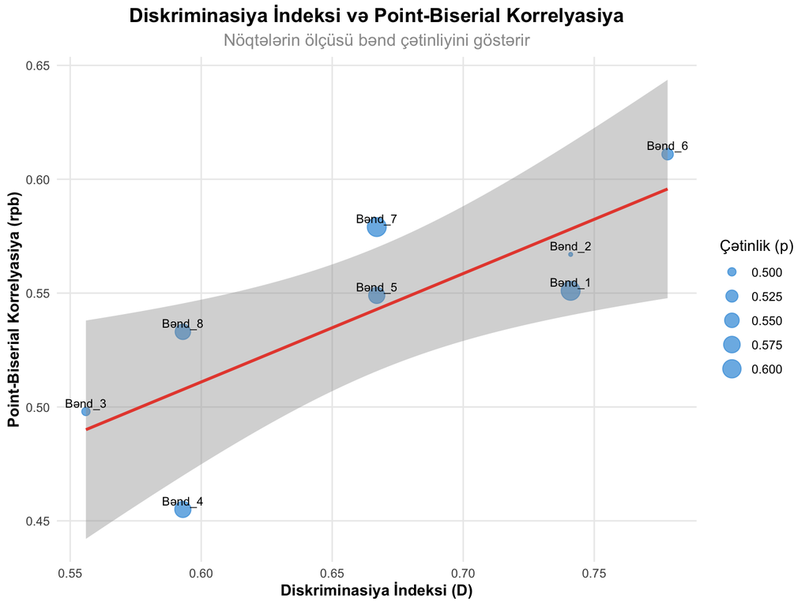

```r
# Point-biserial və diskriminasiya arasındakı əlaqə
comparison_data <- data.frame(
  Bənd = paste0("Bənd_", 1:n_items),
  Diskriminasiya_D = detailed_discrimination$Diskriminasiya_D,
  Point_Biserial_rpb = pb_results$rpb_Birbaşa,
  Çətinlik_p = detailed_discrimination$Çətinlik_p
)

# Əlaqənin vizuallaşdırılması
ggplot(comparison_data, aes(x = Diskriminasiya_D, y = Point_Biserial_rpb)) +
  geom_point(aes(size = Çətinlik_p), alpha = 0.7, color = colors_basic[1]) +
  geom_smooth(method = "lm", se = TRUE, color = colors_basic[2]) +
  geom_text(aes(label = Bənd), vjust = -0.5, size = 3) +
  labs(title = "Diskriminasiya İndeksi və Point-Biserial Korrelyasiya",
       subtitle = "Nöqtələrin ölçüsü bənd çətinliyini göstərir",
       x = "Diskriminasiya İndeksi (D)",
       y = "Point-Biserial Korrelyasiya (rpb)",
       size = "Çətinlik (p)") +
  theme_clean()
```

```r
cat("D və rpb arasında korrelyasiya:", round(cor(comparison_data$Diskriminasiya_D,
                                                comparison_data$Point_Biserial_rpb), 3))
```

```
## D və rpb arasında korrelyasiya: 0.801
```

## 3.2 Biserial Korrelyasiya (rb)

**Biserial korrelyasiya** - əsas davamlı dəyişənin ikili kateqoriyalara bölünməsi zamanı istifadə olunur.

```r
# Biserial korrelyasiya hesablanması
calculate_biserial <- function(item_scores, total_scores) {
  # Point-biserial əvvəlcə
  rpb <- cor(item_scores, total_scores)

  # Bənd statistikaları
  p <- mean(item_scores)
  q <- 1 - p

  # Normal paylanma ordinatı p nöqtəsində
  z_ordinate <- dnorm(qnorm(p))

  # Biserial korrelyasiya
  rb <- rpb * sqrt(p * q) / z_ordinate

  return(list(
    biserial = rb,
    point_biserial = rpb,
    difficulty = p,
    z_ordinate = z_ordinate
  ))
}

# Hər bənd üçün biserial hesablanması
biserial_results <- data.frame()
for(i in 1:n_items) {
  bis_calc <- calculate_biserial(test_data[, i], total_scores)

  temp_result <- data.frame(
    Bənd = paste0("Bənd_", i),
    Point_Biserial_rpb = round(bis_calc$point_biserial, 3),
    Biserial_rb = round(bis_calc$biserial, 3),
    Düzəliş_Nisbəti = round(bis_calc$biserial / bis_calc$point_biserial, 2),
    Çətinlik_p = round(bis_calc$difficulty, 3)
  )

  biserial_results <- rbind(biserial_results, temp_result)
}

kable(biserial_results, caption = "Biserial və Point-Biserial Korrelyasiyaların Müqayisəsi")
```

Biserial və Point-Biserial Korrelyasiyaların Müqayisəsi

| Bənd | Point_Biserial_rpb | Biserial_rb | Düzəliş_Nisbəti | Çətinlik_p |
| --- | --- | --- | --- | --- |
| Bənd_1 | 0.551 | 0.700 | 1.27 | 0.61 |
| Bənd_2 | 0.567 | 0.710 | 1.25 | 0.49 |
| Bənd_3 | 0.498 | 0.624 | 1.25 | 0.50 |
| Bənd_4 | 0.455 | 0.574 | 1.26 | 0.57 |
| Bənd_5 | 0.549 | 0.692 | 1.26 | 0.57 |
| Bənd_6 | 0.611 | 0.766 | 1.25 | 0.52 |
| Bənd_7 | 0.579 | 0.736 | 1.27 | 0.61 |
| Bənd_8 | 0.533 | 0.671 | 1.26 | 0.56 |

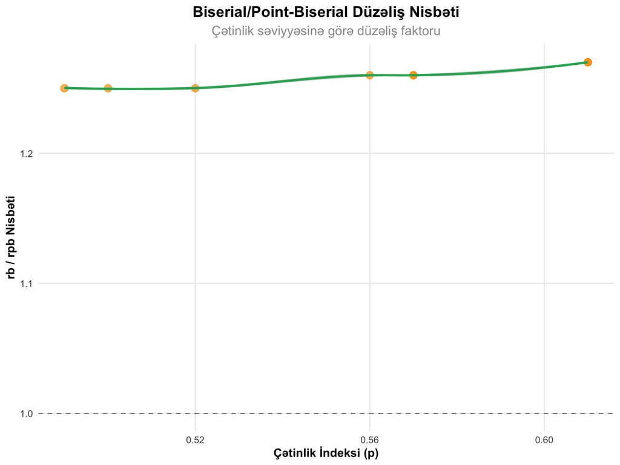

```r
# Düzəliş nisbətinin çətinliklə əlaqəsi
ggplot(biserial_results, aes(x = Çətinlik_p, y = Düzəliş_Nisbəti)) +
  geom_point(size = 3, alpha = 0.7, color = colors_basic[3]) +
  geom_smooth(method = "loess", se = TRUE, color = colors_basic[4]) +
  geom_hline(yintercept = 1, linetype = "dashed", alpha = 0.5) +
  labs(title = "Biserial/Point-Biserial Düzəliş Nisbəti",
       subtitle = "Çətinlik səviyyəsinə görə düzəliş faktoru",
       x = "Çətinlik İndeksi (p)", y = "rb / rpb Nisbəti") +
  theme_clean()
```

# 4 Diskriminasiya İndekslərinin Müqayisəsi

## 4.1 Müxtəlif İndekslərin Xarakteristikaları

```r
# Diskriminasiya indekslərinin müqayisəsi
indices_comparison <- data.frame(
  İndeks = c("Diskriminasiya D", "Point-Biserial rpb", "Biserial rb",
             "Item-Total r", "Corrected Item-Total r"),
  Aralıq = c("-1.0 to +1.0", "-1.0 to +1.0", "-∞ to +∞",
             "-1.0 to +1.0", "-1.0 to +1.0"),
  Üstünlük = c("Sadə hesablama", "Standart korrelyasiya", "Nəzəri düzgün",
               "Ümumi test əlaqəsi", "Inflasiya düzəlişi"),
  Məhdudiyyət = c("Qrup böyüklüyünə həssas", "Çətinlik təsiri", "Hesablama mürəkkəb",
                  "Bənd inflasiyası", "İtki informasiya"),
  Tövsiyə_Halı = c("Standart analiz", "Korrelyasiya konteksti", "Nəzəri tədqiqat",
                   "Etibarlılıq analizi", "Bənd seçimi")
)

kable(indices_comparison, caption = "Diskriminasiya İndekslərinin Xarakteristik Müqayisəsi")
```

Diskriminasiya İndekslərinin Xarakteristik Müqayisəsi

| İndeks | Aralıq | Üstünlük | Məhdudiyyət | Tövsiyə_Halı |
| --- | --- | --- | --- | --- |
| Diskriminasiya D | -1.0 to +1.0 | Sadə hesablama | Qrup böyüklüyünə həssas | Standart analiz |
| Point-Biserial rpb | -1.0 to +1.0 | Standart korrelyasiya | Çətinlik təsiri | Korrelyasiya konteksti |
| Biserial rb | -∞ to +∞ | Nəzəri düzgün | Hesablama mürəkkəb | Nəzəri tədqiqat |
| Item-Total r | -1.0 to +1.0 | Ümumi test əlaqəsi | Bənd inflasiyası | Etibarlılıq analizi |
| Corrected Item-Total r | -1.0 to +1.0 | Inflasiya düzəlişi | İtki informasiya | Bənd seçimi |

```r
# Müxtəlif indekslərin praktik nəticələri
corrected_item_total <- apply(test_data, 2, function(x) {
  total_minus_item <- rowSums(test_data) - x
  cor(x, total_minus_item)
})

all_indices <- data.frame(
  Bənd = paste0("Bənd_", 1:n_items),
  D_Diskriminasiya = detailed_discrimination$Diskriminasiya_D,
  rpb_Point_Biserial = pb_results$rpb_Birbaşa,
  rb_Biserial = biserial_results$Biserial_rb,
  r_Item_Total = round(detailed_discrimination$Point_Biserial_r, 3),
  r_Corrected = round(corrected_item_total, 3)
)

kable(all_indices, caption = "Bütün Diskriminasiya İndekslərinin Praktik Nəticələri")
```

Bütün Diskriminasiya İndekslərinin Praktik Nəticələri

|  | Bənd | D_Diskriminasiya | rpb_Point_Biserial | rb_Biserial | r_Item_Total | r_Corrected |
| --- | --- | --- | --- | --- | --- | --- |
| Bənd_1 | Bənd_1 | 0.741 | 0.551 | 0.700 | 0.362 | 0.362 |
| Bənd_2 | Bənd_2 | 0.741 | 0.567 | 0.710 | 0.376 | 0.376 |
| Bənd_3 | Bənd_3 | 0.556 | 0.498 | 0.624 | 0.292 | 0.292 |
| Bənd_4 | Bənd_4 | 0.593 | 0.455 | 0.574 | 0.245 | 0.245 |
| Bənd_5 | Bənd_5 | 0.667 | 0.549 | 0.692 | 0.357 | 0.357 |
| Bənd_6 | Bənd_6 | 0.778 | 0.611 | 0.766 | 0.431 | 0.431 |
| Bənd_7 | Bənd_7 | 0.667 | 0.579 | 0.736 | 0.397 | 0.397 |
| Bənd_8 | Bənd_8 | 0.593 | 0.533 | 0.671 | 0.337 | 0.337 |

## 4.2 İndekslər Arası Korrelyasiyalar

```r
# İndekslər arasında korrelyasiya matrisi
correlation_matrix <- cor(all_indices[, -1])
correlation_df <- as.data.frame(round(correlation_matrix, 3))

kable(correlation_df, caption = "Diskriminasiya İndeksləri Arasında Korrelyasiya Matrisi")
```

Diskriminasiya İndeksləri Arasında Korrelyasiya Matrisi

|  | D_Diskriminasiya | rpb_Point_Biserial | rb_Biserial | r_Item_Total | r_Corrected |
| --- | --- | --- | --- | --- | --- |
| D_Diskriminasiya | 1.000 | 0.801 | 0.800 | 0.804 | 0.804 |
| rpb_Point_Biserial | 0.801 | 1.000 | 0.998 | 0.999 | 0.999 |
| rb_Biserial | 0.800 | 0.998 | 1.000 | 0.999 | 0.999 |
| r_Item_Total | 0.804 | 0.999 | 0.999 | 1.000 | 1.000 |
| r_Corrected | 0.804 | 0.999 | 0.999 | 1.000 | 1.000 |

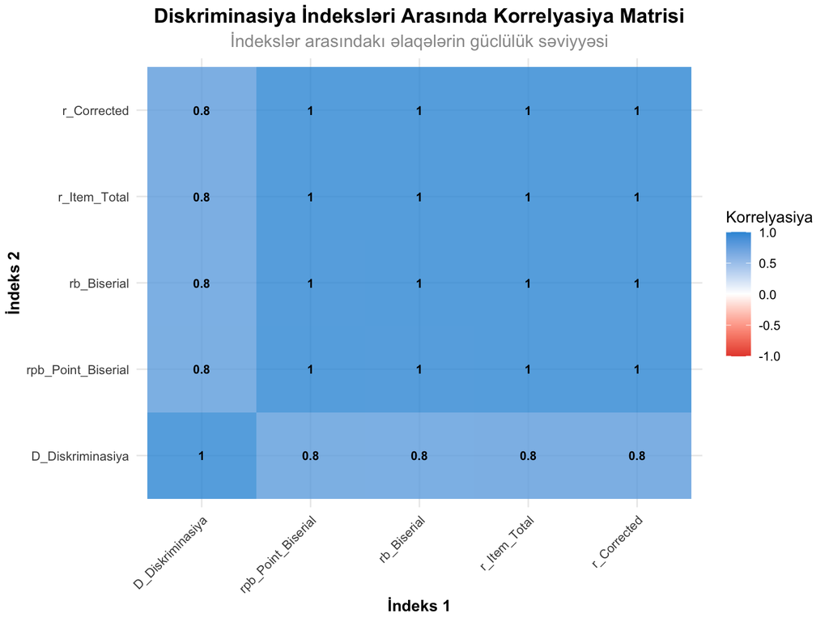

```r
# Korrelyasiya matrisinin heatmap vizuallaşdırılması
correlation_long <- expand.grid(
  İndeks1 = rownames(correlation_matrix),
  İndeks2 = colnames(correlation_matrix)
) %>%
  mutate(Korrelyasiya = as.vector(correlation_matrix))

ggplot(correlation_long, aes(x = İndeks1, y = İndeks2, fill = Korrelyasiya)) +
  geom_tile(alpha = 0.8) +
  geom_text(aes(label = round(Korrelyasiya, 2)), fontface = "bold", size = 3) +
  scale_fill_gradient2(low = colors_basic[2], mid = "white", high = colors_basic[1],
                       midpoint = 0, limits = c(-1, 1)) +
  labs(title = "Diskriminasiya İndeksləri Arasında Korrelyasiya Matrisi",
       subtitle = "İndekslər arasındakı əlaqələrin güclülük səviyyəsi",
       x = "İndeks 1", y = "İndeks 2", fill = "Korrelyasiya") +
  theme_clean() +
  theme(axis.text.x = element_text(angle = 45, hjust = 1))
```

## 4.3 Praktik Tövsiyələr

```r
# Hər bənd üçün ən uyğun indeksin tövsiyəsi
recommendations <- data.frame(
  Bənd = paste0("Bənd_", 1:n_items),
  Çətinlik_p = detailed_discrimination$Çətinlik_p,
  Diskriminasiya_D = detailed_discrimination$Diskriminasiya_D,
  Point_Biserial = pb_results$rpb_Birbaşa,
  Tövsiyə = case_when(
    detailed_discrimination$Diskriminasiya_D >= 0.30 ~ "Saxla - Yaxşı diskriminasiya",
    detailed_discrimination$Diskriminasiya_D >= 0.20 ~ "Yaxşılaşdır - Orta diskriminasiya",
    detailed_discrimination$Diskriminasiya_D >= 0.00 ~ "Ciddi yaxşılaşdır - Zəif diskriminasiya",
    TRUE ~ "Sil və ya tamamilə yenidən yaz - Neqativ diskriminasiya"
  ),
  Prioritet = case_when(
    detailed_discrimination$Diskriminasiya_D < 0.00 ~ "Təcili",
    detailed_discrimination$Diskriminasiya_D < 0.20 ~ "Yüksək",
    detailed_discrimination$Diskriminasiya_D < 0.30 ~ "Orta",
    TRUE ~ "Aşağı"
  )
)

kable(recommendations, caption = "Bəndlər üçün Fərdiləşdirilmiş Yaxşılaşdırma Tövsiyələri")
```

Bəndlər üçün Fərdiləşdirilmiş Yaxşılaşdırma Tövsiyələri

| Bənd | Çətinlik_p | Diskriminasiya_D | Point_Biserial | Tövsiyə | Prioritet |
| --- | --- | --- | --- | --- | --- |
| Bənd_1 | 0.61 | 0.741 | 0.551 | Saxla - Yaxşı diskriminasiya | Aşağı |
| Bənd_2 | 0.49 | 0.741 | 0.567 | Saxla - Yaxşı diskriminasiya | Aşağı |
| Bənd_3 | 0.50 | 0.556 | 0.498 | Saxla - Yaxşı diskriminasiya | Aşağı |
| Bənd_4 | 0.57 | 0.593 | 0.455 | Saxla - Yaxşı diskriminasiya | Aşağı |
| Bənd_5 | 0.57 | 0.667 | 0.549 | Saxla - Yaxşı diskriminasiya | Aşağı |
| Bənd_6 | 0.52 | 0.778 | 0.611 | Saxla - Yaxşı diskriminasiya | Aşağı |
| Bənd_7 | 0.61 | 0.667 | 0.579 | Saxla - Yaxşı diskriminasiya | Aşağı |
| Bənd_8 | 0.56 | 0.593 | 0.533 | Saxla - Yaxşı diskriminasiya | Aşağı |

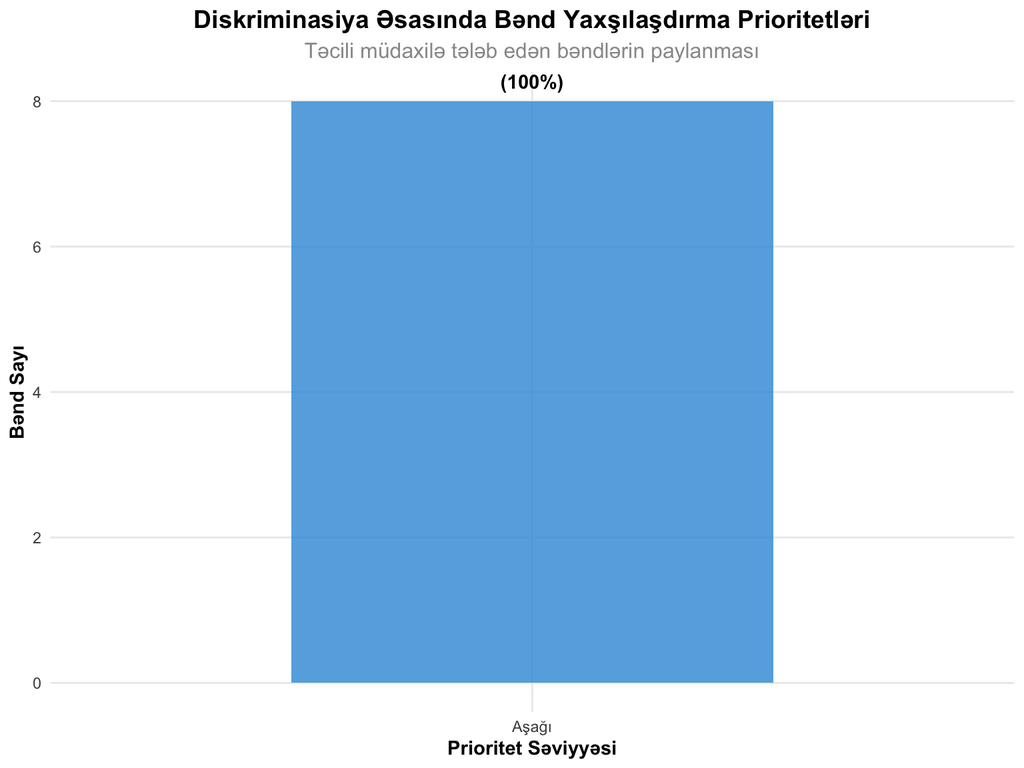

```r
# Prioritet səviyyələrinin paylanması
priority_summary <- recommendations %>%
  count(Prioritet) %>%
  mutate(Faiz = round(n/sum(n)*100, 1))

ggplot(priority_summary, aes(x = factor(Prioritet, levels = c("Təcili", "Yüksək", "Orta", "Aşağı")),
                            y = n, fill = Prioritet)) +
  geom_col(alpha = 0.8, width = 0.6) +
  geom_text(aes(label = paste0(n, " bənd\n(", Faiz, "%)")),
            vjust = -0.3, fontface = "bold") +
  scale_fill_manual(values = c("Təcili" = colors_basic[2], "Yüksək" = colors_basic[3],
                               "Orta" = colors_basic[4], "Aşağı" = colors_basic[1])) +
  labs(title = "Diskriminasiya Əsasında Bənd Yaxşılaşdırma Prioritetləri",
       subtitle = "Təcili müdaxilə tələb edən bəndlərin paylanması",
       x = "Prioritet Səviyyəsi", y = "Bənd Sayı", fill = "Prioritet") +
  theme_clean() +
  theme(legend.position = "none")
```

# 5 Diskriminasiya Analizində Xüsusi Vəziyyətlər

## 5.1 Neqativ Diskriminasiya Problemi

```r
# Neqativ diskriminasiyalı bəndlərin təhlili
negative_items <- recommendations[recommendations$Diskriminasiya_D < 0, ]

if(nrow(negative_items) > 0) {
  kable(negative_items, caption = "Neqativ Diskriminasiya Göstərən Problemli Bəndlər")

  # Neqativ diskriminasiyanın səbəbləri
  negative_causes <- data.frame(
    Səbəb = c("Açar xətası", "Çaşdırıcı təlimat", "Çox çətin məzmun",
              "Yanlış distractor", "Mədəni qərəzlik", "Texniki problem"),
    Simptom = c("Yüksək qabiliyyətlilər səhv seçir", "Anlaşılmır", "Təsadüfi cavablama",
                "Doğru cavab cəlbedici deyil", "Müəyyən qrupa ədalətsiz", "Sistem problemi"),
    Həll = c("Açarı yoxla və düzəlt", "Təlimatı sadələşdir", "Çətinliyi azalt",
             "Distractorları yaxşılaşdır", "Mədəni nəzərdən keçir", "Texniki yoxlama")
  )

  kable(negative_causes, caption = "Neqativ Diskriminasiyanın Səbəbləri və Həll Yolları")
} else {
  cat("Bu testdə neqativ diskriminasiyalı bənd yoxdur.\n")
}
```

```
## Bu testdə neqativ diskriminasiyalı bənd yoxdur.
```

```r
# Neqativ diskriminasiya simulyasiyası (nümunə üçün)
set.seed(456)
problematic_responses <- rbinom(n_students, 1, 0.4)  # Ümumi çətinlik
# Yüksək qabiliyyətlilər daha az doğru cavab verir
problematic_responses[upper_indices] <- rbinom(length(upper_indices), 1, 0.2)
# Aşağı qabiliyyətlilər daha çox doğru cavab verir
problematic_responses[lower_indices] <- rbinom(length(lower_indices), 1, 0.6)

negative_example <- data.frame(
  Qrup = c("Üst %27", "Alt %27", "Ümumi"),
  Doğru_Sayı = c(sum(problematic_responses[upper_indices]),
                  sum(problematic_responses[lower_indices]),
                  sum(problematic_responses)),
  İştirakçı_Sayı = c(length(upper_indices), length(lower_indices), n_students),
  p_İndeksi = c(mean(problematic_responses[upper_indices]),
                mean(problematic_responses[lower_indices]),
                mean(problematic_responses)),
  Diskriminasiya_D = c(NA, NA, mean(problematic_responses[upper_indices]) -
                              mean(problematic_responses[lower_indices]))
)

kable(negative_example, caption = "Neqativ Diskriminasiya Nümunəsi", digits = 3)
```

Neqativ Diskriminasiya Nümunəsi

| Qrup | Doğru_Sayı | İştirakçı_Sayı | p_İndeksi | Diskriminasiya_D |
| --- | --- | --- | --- | --- |
| Üst %27 | 6 | 27 | 0.222 | NA |
| Alt %27 | 16 | 27 | 0.593 | NA |
| Ümumi | 44 | 100 | 0.440 | -0.37 |

## 5.2 Çətinlik və Diskriminasiya Balansı

```r
# Çətinlik və diskriminasiya arasındakı optimal balansın təhlili
balance_analysis <- data.frame(
  Çətinlik_Kateqoriyası = c("Çox Asan (p > 0.85)", "Asan (0.70 < p ≤ 0.85)",
                           "Orta (0.30 ≤ p ≤ 0.70)", "Çətin (0.15 ≤ p < 0.30)",
                           "Çox Çətin (p < 0.15)"),
  Gözlənilən_D = c("Aşağı (< 0.20)", "Aşağı-Orta (0.15-0.30)",
                   "Yüksək (> 0.30)", "Orta (0.20-0.35)", "Aşağı (< 0.15)"),
  Tövsiyə = c("Çətinləşdirin", "Diskriminasiyanı artırın",
              "Saxlayın", "Asanlaşdırın", "Əsaslı dəyişiklik"),
  Səbəb = c("Tavan effekti", "Məhdud variasiya",
            "Optimal variasiya", "Məhdud variasiya", "Döşəmə effekti")
)

kable(balance_analysis, caption = "Çətinlik və Diskriminasiya Balansının Analizi")
```

Çətinlik və Diskriminasiya Balansının Analizi

| Çətinlik_Kateqoriyası | Gözlənilən_D | Tövsiyə | Səbəb |
| --- | --- | --- | --- |
| Çox Asan (p > 0.85) | Aşağı (< 0.20) | Çətinləşdirin | Tavan effekti |
| Asan (0.70 < p ≤ 0.85) | Aşağı-Orta (0.15-0.30) | Diskriminasiyanı artırın | Məhdud variasiya |
| Orta (0.30 ≤ p ≤ 0.70) | Yüksək (> 0.30) | Saxlayın | Optimal variasiya |
| Çətin (0.15 ≤ p < 0.30) | Orta (0.20-0.35) | Asanlaşdırın | Məhdud variasiya |
| Çox Çətin (p < 0.15) | Aşağı (< 0.15) | Əsaslı dəyişiklik | Döşəmə effekti |

```r
# Test məlumatlarından real nümunə
real_balance <- detailed_discrimination %>%
  mutate(
    Çətinlik_Kateqoriyası = case_when(
      Çətinlik_p > 0.85 ~ "Çox Asan",
      Çətinlik_p > 0.70 ~ "Asan",
      Çətinlik_p >= 0.30 ~ "Orta",
      Çətinlik_p >= 0.15 ~ "Çətin",
      TRUE ~ "Çox Çətin"
    )
  ) %>%
  group_by(Çətinlik_Kateqoriyası) %>%
  summarise(
    Bənd_Sayı = n(),
    Orta_D = round(mean(Diskriminasiya_D), 3),
    Min_D = round(min(Diskriminasiya_D), 3),
    Max_D = round(max(Diskriminasiya_D), 3),
    .groups = 'drop'
  )

kable(real_balance, caption = "Cari Testdə Çətinlik-Diskriminasiya Balansı")
```

Cari Testdə Çətinlik-Diskriminasiya Balansı

| Çətinlik_Kateqoriyası | Bənd_Sayı | Orta_D | Min_D | Max_D |
| --- | --- | --- | --- | --- |
| Orta | 8 | 0.667 | 0.556 | 0.778 |

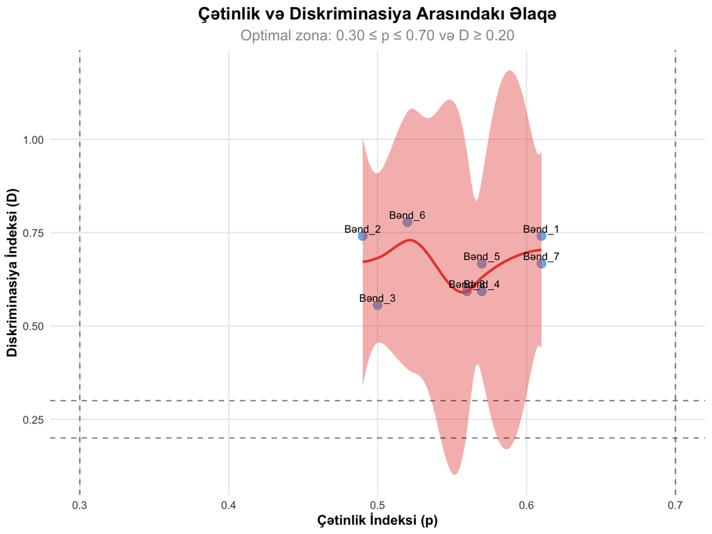

```r
# Balans vizuallaşdırması
ggplot(detailed_discrimination, aes(x = Çətinlik_p, y = Diskriminasiya_D)) +
  geom_point(size = 3, alpha = 0.7, color = colors_basic[1]) +
  geom_smooth(method = "loess", se = TRUE, color = colors_basic[2], fill = colors_basic[2]) +
  geom_vline(xintercept = c(0.30, 0.70), linetype = "dashed", alpha = 0.5) +
  geom_hline(yintercept = c(0.20, 0.30), linetype = "dashed", alpha = 0.5) +
  geom_text(aes(label = Bənd), vjust = -0.5, size = 3) +
  labs(title = "Çətinlik və Diskriminasiya Arasındakı Əlaqə",
       subtitle = "Optimal zona: 0.30 ≤ p ≤ 0.70 və D ≥ 0.20",
       x = "Çətinlik İndeksi (p)", y = "Diskriminasiya İndeksi (D)") +
  theme_clean()
```

# 6 R-da Hərtərəfli Diskriminasiya Analizi

## 6.1 Avtomatik Analiz Funksiyası

```r
# Hərtərəfli diskriminasiya analizi funksiyası
comprehensive_discrimination_analysis <- function(data, method = "27%", group_var = NULL) {

  n_items <- ncol(data)
  n_students <- nrow(data)

  results <- list()

  # 1. Ümumi balların hesablanması
  total_scores <- rowSums(data, na.rm = TRUE)

  # 2. Qrupların təyini
  if(method == "27%") {
    n_extreme <- round(0.27 * n_students)
  } else if(method == "33%") {
    n_extreme <- round(0.33 * n_students)
  } else {
    n_extreme <- round(0.25 * n_students)  # Default 25%
  }

  upper_indices <- order(total_scores, decreasing = TRUE)[1:n_extreme]
  lower_indices <- order(total_scores, decreasing = FALSE)[1:n_extreme]

  # 3. Hər bənd üçün analiz
  item_analysis <- data.frame()

  for(i in 1:n_items) {
    item_scores <- data[, i]

    # Əsas statistikalar
    p_total <- mean(item_scores, na.rm = TRUE)
    p_upper <- mean(item_scores[upper_indices], na.rm = TRUE)
    p_lower <- mean(item_scores[lower_indices], na.rm = TRUE)
    D <- p_upper - p_lower

    # Point-biserial korrelyasiya
    rpb <- cor(item_scores, total_scores, use = "complete.obs")

    # Corrected item-total korrelyasiya
    total_minus_item <- total_scores - item_scores
    corrected_r <- cor(item_scores, total_minus_item, use = "complete.obs")

    # Biserial korrelyasiya
    z_ordinate <- dnorm(qnorm(p_total))
    rb <- rpb * sqrt(p_total * (1 - p_total)) / z_ordinate

    # Standart xəta
    se_D <- sqrt(p_upper * (1 - p_upper) / n_extreme +
                 p_lower * (1 - p_lower) / n_extreme)

    # Keyfiyyət qiyməti
    quality <- case_when(
      D >= 0.40 ~ "Çox Yaxşı",
      D >= 0.30 ~ "Yaxşı",
      D >= 0.20 ~ "Orta",
      D >= 0.00 ~ "Zəif",
      TRUE ~ "Neqativ"
    )

    temp_result <- data.frame(
      Bənd = colnames(data)[i],
      n_Üst = n_extreme,
      n_Alt = n_extreme,
      p_Üst = round(p_upper, 3),
      p_Alt = round(p_lower, 3),
      p_Ümumi = round(p_total, 3),
      D = round(D, 3),
      SE_D = round(se_D, 3),
      rpb = round(rpb, 3),
      rb = round(rb, 3),
      r_corrected = round(corrected_r, 3),
      Keyfiyyət = quality
    )

    item_analysis <- rbind(item_analysis, temp_result)
  }

  results$item_analysis <- item_analysis

  # 4. Ümumi test statistikaları
  results$test_statistics <- list(
    n_items = n_items,
    n_students = n_students,
    mean_difficulty = mean(item_analysis$p_Ümumi),
    mean_discrimination = mean(item_analysis$D),
    reliability_alpha = psych::alpha(data)$total$raw_alpha,
    good_items = sum(item_analysis$D >= 0.30),
    poor_items = sum(item_analysis$D < 0.20)
  )

  return(results)
}

# Test məlumatları üçün hərtərəfli analiz
full_analysis <- comprehensive_discrimination_analysis(test_data)

# Nəticələrin göstərilməsi
kable(full_analysis$item_analysis, caption = "Hərtərəfli Diskriminasiya Analizi Nəticələri")
```

Hərtərəfli Diskriminasiya Analizi Nəticələri

| Bənd | n_Üst | n_Alt | p_Üst | p_Alt | p_Ümumi | D | SE_D | rpb | rb | r_corrected | Keyfiyyət |
| --- | --- | --- | --- | --- | --- | --- | --- | --- | --- | --- | --- |
| Bənd_1 | 27 | 27 | 0.963 | 0.222 | 0.61 | 0.741 | 0.088 | 0.551 | 0.700 | 0.362 | Çox Yaxşı |
| Bənd_2 | 27 | 27 | 0.926 | 0.185 | 0.49 | 0.741 | 0.090 | 0.567 | 0.710 | 0.376 | Çox Yaxşı |
| Bənd_3 | 27 | 27 | 0.741 | 0.185 | 0.50 | 0.556 | 0.113 | 0.498 | 0.624 | 0.292 | Çox Yaxşı |
| Bənd_4 | 27 | 27 | 0.926 | 0.333 | 0.57 | 0.593 | 0.104 | 0.455 | 0.574 | 0.245 | Çox Yaxşı |
| Bənd_5 | 27 | 27 | 0.889 | 0.222 | 0.57 | 0.667 | 0.100 | 0.549 | 0.692 | 0.357 | Çox Yaxşı |
| Bənd_6 | 27 | 27 | 0.926 | 0.148 | 0.52 | 0.778 | 0.085 | 0.611 | 0.766 | 0.431 | Çox Yaxşı |
| Bənd_7 | 27 | 27 | 0.889 | 0.222 | 0.61 | 0.667 | 0.100 | 0.579 | 0.736 | 0.397 | Çox Yaxşı |
| Bənd_8 | 27 | 27 | 0.815 | 0.222 | 0.56 | 0.593 | 0.109 | 0.533 | 0.671 | 0.337 | Çox Yaxşı |

```r
# Test statistikaları
test_stats <- full_analysis$test_statistics
cat("Test Statistikalarının Xülasəsi:\n")
```

```
## Test Statistikalarının Xülasəsi:
```

```r
cat("Bənd sayı:", test_stats$n_items, "\n")
```

```
## Bənd sayı: 8
```

```r
cat("Tələbə sayı:", test_stats$n_students, "\n")
```

```
## Tələbə sayı: 100
```

```r
cat("Orta çətinlik:", round(test_stats$mean_difficulty, 3), "\n")
```

```
## Orta çətinlik: 0.554
```

```r
cat("Orta diskriminasiya:", round(test_stats$mean_discrimination, 3), "\n")
```

```
## Orta diskriminasiya: 0.667
```

```r
cat("Cronbach Alpha:", round(test_stats$reliability_alpha, 3), "\n")
```

```
## Cronbach Alpha: 0.658
```

```r
cat("Yaxşı bəndlər (D ≥ 0.30):", test_stats$good_items, "\n")
```

```
## Yaxşı bəndlər (D ≥ 0.30): 8
```

```r
cat("Zəif bəndlər (D < 0.20):", test_stats$poor_items, "\n")
```

```
## Zəif bəndlər (D < 0.20): 0
```

## 6.2 İnteraktiv Diskriminasiya Xəritəsi

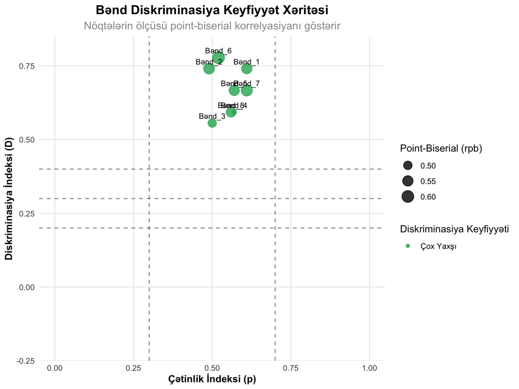

```r
# Diskriminasiya keyfiyyət xəritəsi
quality_map <- full_analysis$item_analysis %>%
  mutate(
    Çətinlik_Kateqoriyası = case_when(
      p_Ümumi > 0.85 ~ "Çox Asan",
      p_Ümumi > 0.70 ~ "Asan",
      p_Ümumi >= 0.30 ~ "Orta",
      p_Ümumi >= 0.15 ~ "Çətin",
      TRUE ~ "Çox Çətin"
    ),
    Diskriminasiya_Kateqoriyası = case_when(
      D >= 0.40 ~ "Çox Yaxşı",
      D >= 0.30 ~ "Yaxşı",
      D >= 0.20 ~ "Orta",
      D >= 0.00 ~ "Zəif",
      TRUE ~ "Neqativ"
    )
  )

# Çox ölçülü keyfiyyət xəritəsi
ggplot(quality_map, aes(x = p_Ümumi, y = D)) +
  geom_point(aes(color = Keyfiyyət, size = rpb), alpha = 0.8) +
  geom_vline(xintercept = c(0.30, 0.70), linetype = "dashed", alpha = 0.5) +
  geom_hline(yintercept = c(0.20, 0.30, 0.40), linetype = "dashed", alpha = 0.5) +
  geom_text(aes(label = Bənd), vjust = -0.8, size = 3) +
  scale_color_manual(values = c("Çox Yaxşı" = colors_basic[4], "Yaxşı" = colors_basic[3],
                                "Orta" = colors_basic[1], "Zəif" = colors_basic[2],
                                "Neqativ" = colors_basic[5])) +
  scale_size_continuous(range = c(2, 6)) +
  labs(title = "Bənd Diskriminasiya Keyfiyyət Xəritəsi",
       subtitle = "Nöqtələrin ölçüsü point-biserial korrelyasiyanı göstərir",
       x = "Çətinlik İndeksi (p)", y = "Diskriminasiya İndeksi (D)",
       color = "Diskriminasiya Keyfiyyəti", size = "Point-Biserial (rpb)") +
  theme_clean() +
  xlim(0, 1) + ylim(-0.2, 0.8)
```

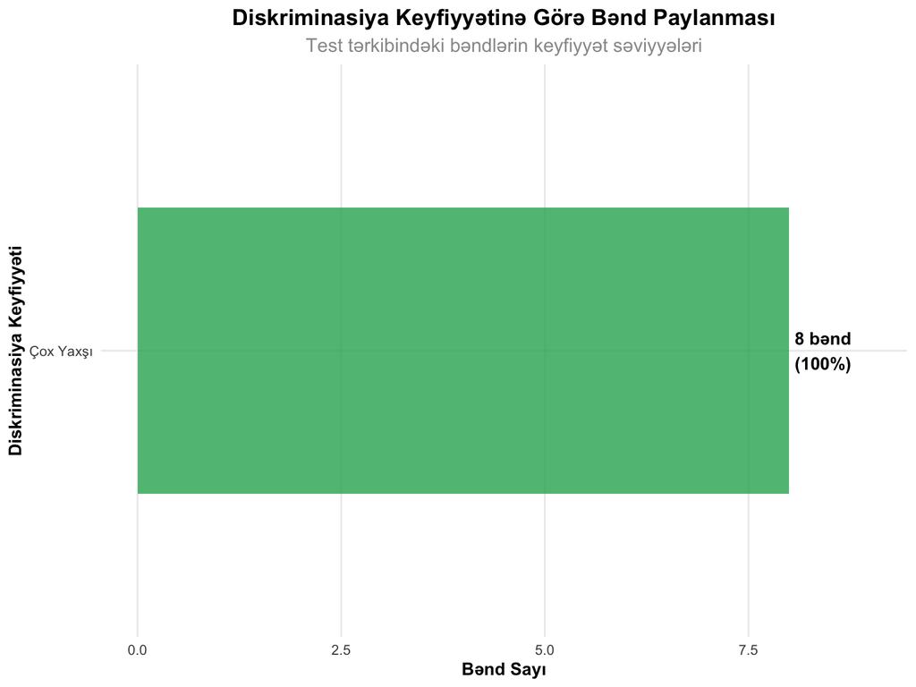

```r
# Keyfiyyət kateqoriyalarının paylanması
quality_distribution <- quality_map %>%
  count(Keyfiyyət) %>%
  mutate(Faiz = round(n/sum(n)*100, 1))

ggplot(quality_distribution, aes(x = reorder(Keyfiyyət, n), y = n, fill = Keyfiyyət)) +
  geom_col(alpha = 0.8, width = 0.6) +
  geom_text(aes(label = paste0(n, " bənd\n(", Faiz, "%)")),
            hjust = -0.1, fontface = "bold") +
  coord_flip() +
  scale_fill_manual(values = c("Çox Yaxşı" = colors_basic[4], "Yaxşı" = colors_basic[3],
                               "Orta" = colors_basic[1], "Zəif" = colors_basic[2],
                               "Neqativ" = colors_basic[5])) +
  labs(title = "Diskriminasiya Keyfiyyətinə Görə Bənd Paylanması",
       subtitle = "Test tərkibindəki bəndlərin keyfiyyət səviyyələri",
       x = "Diskriminasiya Keyfiyyəti", y = "Bənd Sayı") +
  theme_clean() +
  theme(legend.position = "none") +
  ylim(0, max(quality_distribution$n) + 1)
```

# 7 Diskriminasiya Təkmilləşdirmə Strategiyaları

## 7.1 Bənd Yaxşılaşdırma Protokolu

```r
# Hər keyfiyyət kateqoriyası üçün yaxşılaşdırma strategiyaları
improvement_strategies <- data.frame(
  Diskriminasiya_Səviyyəsi = c("Neqativ (D < 0)", "Zəif (0 ≤ D < 0.20)",
                               "Orta (0.20 ≤ D < 0.30)", "Yaxşı (0.30 ≤ D < 0.40)",
                               "Çox Yaxşı (D ≥ 0.40)"),
  Təcili_Addım = c("Fövri ləğv et", "Kökündən yenidən yaz",
                   "Distractorları yaxşılaşdır", "Kiçik düzəlişlər", "Saxla"),
  Uzunmüddətli_Plan = c("Yeni bənd yarat", "Məzmun analizi",
                        "Pilot test et", "Validlik yoxla", "Bənd bankında saxla"),
  Gözlənilən_Müddət = c("Dərhal", "2-3 həftə", "1-2 həftə", "Bir neçə gün", "Fəaliyyət yox"),
  Resursa_Ehtiyac = c("Az", "Yüksək", "Orta", "Az", "Yox")
)

kable(improvement_strategies, caption = "Diskriminasiya Səviyyəsinə Görə Yaxşılaşdırma Strategiyaları")
```

Diskriminasiya Səviyyəsinə Görə Yaxşılaşdırma Strategiyaları

| Diskriminasiya_Səviyyəsi | Təcili_Addım | Uzunmüddətli_Plan | Gözlənilən_Müddət | Resursa_Ehtiyac |
| --- | --- | --- | --- | --- |
| Neqativ (D < 0) | Fövri ləğv et | Yeni bənd yarat | Dərhal | Az |
| Zəif (0 ≤ D < 0.20) | Kökündən yenidən yaz | Məzmun analizi | 2-3 həftə | Yüksək |
| Orta (0.20 ≤ D < 0.30) | Distractorları yaxşılaşdır | Pilot test et | 1-2 həftə | Orta |
| Yaxşı (0.30 ≤ D < 0.40) | Kiçik düzəlişlər | Validlik yoxla | Bir neçə gün | Az |
| Çox Yaxşı (D ≥ 0.40) | Saxla | Bənd bankında saxla | Fəaliyyət yox | Yox |

```r
# Konkret yaxşılaşdırma planı
specific_improvements <- quality_map %>%
  mutate(
    Fövri_Hərəkət = case_when(
      D < 0 ~ "SİL - Neqativ diskriminasiya",
      D < 0.20 ~ "YENİDƏN YAZ - Zəif diskriminasiya",
      D < 0.30 ~ "YAXŞILAŞDıR - Distractorları gücləndir",
      D < 0.40 ~ "KIÇIK DÜZƏLIŞ - Mətn dəqiqləşdir",
      TRUE ~ "SAXLA - Yaxşı diskriminasiya"
    ),
    Təfərrüatlı_Plan = case_when(
      D < 0 ~ "Açar cavabı yoxla, distractorları nəzərdən keçir",
      D < 0.20 ~ "Məzmunu təhlil et, yeni formulyasiya yaz",
      D < 0.30 ~ "Cəlbedici distractorlar əlavə et",
      D < 0.40 ~ "Dil və ifadəni sadələşdir",
      TRUE ~ "Bənd bankında qoru"
    )
  ) %>%
  select(Bənd, D, Keyfiyyət, Fövri_Hərəkət, Təfərrüatlı_Plan)

kable(specific_improvements, caption = "Hər Bənd üçün Fərdi Yaxşılaşdırma Planı")
```

Hər Bənd üçün Fərdi Yaxşılaşdırma Planı

| Bənd | D | Keyfiyyət | Fövri_Hərəkət | Təfərrüatlı_Plan |
| --- | --- | --- | --- | --- |
| Bənd_1 | 0.741 | Çox Yaxşı | SAXLA - Yaxşı diskriminasiya | Bənd bankında qoru |
| Bənd_2 | 0.741 | Çox Yaxşı | SAXLA - Yaxşı diskriminasiya | Bənd bankında qoru |
| Bənd_3 | 0.556 | Çox Yaxşı | SAXLA - Yaxşı diskriminasiya | Bənd bankında qoru |
| Bənd_4 | 0.593 | Çox Yaxşı | SAXLA - Yaxşı diskriminasiya | Bənd bankında qoru |
| Bənd_5 | 0.667 | Çox Yaxşı | SAXLA - Yaxşı diskriminasiya | Bənd bankında qoru |
| Bənd_6 | 0.778 | Çox Yaxşı | SAXLA - Yaxşı diskriminasiya | Bənd bankında qoru |
| Bənd_7 | 0.667 | Çox Yaxşı | SAXLA - Yaxşı diskriminasiya | Bənd bankında qoru |
| Bənd_8 | 0.593 | Çox Yaxşı | SAXLA - Yaxşı diskriminasiya | Bənd bankında qoru |

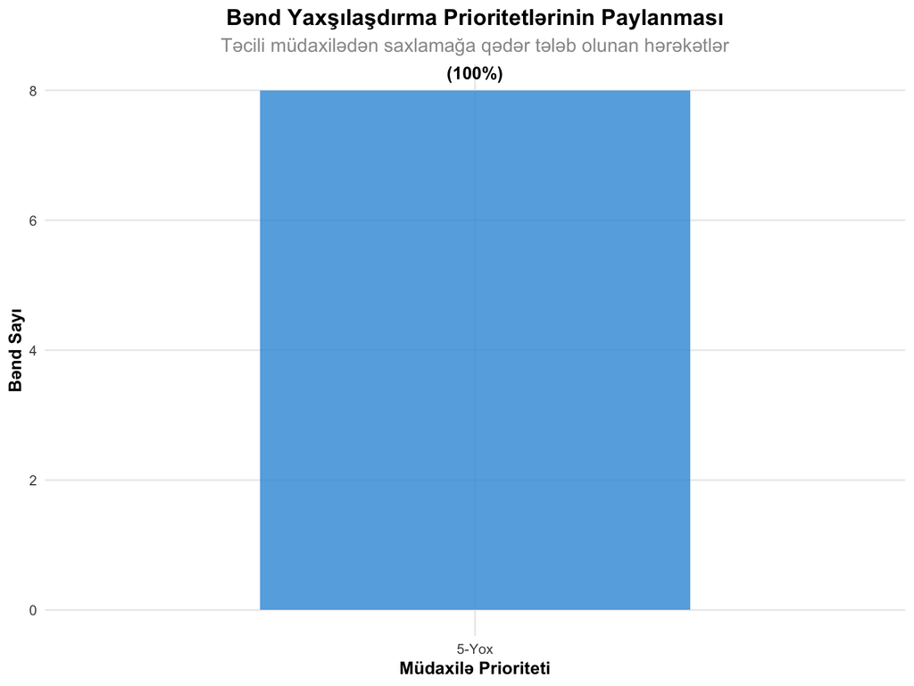

```r
# Yaxşılaşdırma prioritetlərinin visuallaşdırılması
priority_actions <- specific_improvements %>%
  mutate(Prioritet = case_when(
    grepl("SİL", Fövri_Hərəkət) ~ "1-Təcili",
    grepl("YENİDƏN", Fövri_Hərəkət) ~ "2-Yüksək",
    grepl("YAXŞILAŞDıR", Fövri_Hərəkət) ~ "3-Orta",
    grepl("KIÇIK", Fövri_Hərəkət) ~ "4-Aşağı",
    TRUE ~ "5-Yox"
  )) %>%
  count(Prioritet) %>%
  mutate(Faiz = round(n/sum(n)*100, 1))

ggplot(priority_actions, aes(x = Prioritet, y = n, fill = Prioritet)) +
  geom_col(alpha = 0.8, width = 0.6) +
  geom_text(aes(label = paste0(n, " bənd\n(", Faiz, "%)")),
            vjust = -0.3, fontface = "bold") +
  scale_fill_manual(values = colors_basic[1:5]) +
  labs(title = "Bənd Yaxşılaşdırma Prioritetlərinin Paylanması",
       subtitle = "Təcili müdaxilədən saxlamağa qədər tələb olunan hərəkətlər",
       x = "Müdaxilə Prioriteti", y = "Bənd Sayı") +
  theme_clean() +
  theme(legend.position = "none")
```

## 7.2 Müqayisəli Analiz (Əvvəl vs Sonra)

```r
# Yaxşılaşdırmadan əvvəl və sonra simulyasiya
set.seed(789)

# "Sonra" vəziyyətini simulyasiya edək
improved_data <- test_data

# Zəif bəndləri yaxşılaşdıraq
weak_items <- which(full_analysis$item_analysis$D < 0.30)

for(item_idx in weak_items) {
  # Yüksək qabiliyyətlilərdə doğru cavab ehtimalını artıraq
  current_responses <- improved_data[, item_idx]

  # Üst qrupda müəyyən nisbətdə cavabları düzəlt
  improvement_indices <- sample(upper_indices, round(length(upper_indices) * 0.3))
  improved_data[improvement_indices, item_idx] <- 1

  # Alt qrupda bir az azalt
  degradation_indices <- sample(lower_indices, round(length(lower_indices) * 0.1))
  improved_data[degradation_indices, item_idx] <- 0
}

# Yaxşılaşdırılmış məlumatlar üçün analiz
improved_analysis <- comprehensive_discrimination_analysis(improved_data)

# Əvvəl vs Sonra müqayisəsi
comparison_results <- data.frame(
  Bənd = full_analysis$item_analysis$Bənd,
  Əvvəl_D = full_analysis$item_analysis$D,
  Sonra_D = improved_analysis$item_analysis$D,
  Dəyişiklik_D = improved_analysis$item_analysis$D - full_analysis$item_analysis$D,
  Əvvəl_Keyfiyyət = full_analysis$item_analysis$Keyfiyyət,
  Sonra_Keyfiyyət = improved_analysis$item_analysis$Keyfiyyət,
  Yaxşılaşma = improved_analysis$item_analysis$D > full_analysis$item_analysis$D
)

kable(comparison_results, caption = "Bənd Yaxşılaşdırması: Əvvəl və Sonra Müqayisəsi", digits = 3)
```

Bənd Yaxşılaşdırması: Əvvəl və Sonra Müqayisəsi

| Bənd | Əvvəl_D | Sonra_D | Dəyişiklik_D | Əvvəl_Keyfiyyət | Sonra_Keyfiyyət | Yaxşılaşma |
| --- | --- | --- | --- | --- | --- | --- |
| Bənd_1 | 0.741 | 0.741 | 0 | Çox Yaxşı | Çox Yaxşı | FALSE |
| Bənd_2 | 0.741 | 0.741 | 0 | Çox Yaxşı | Çox Yaxşı | FALSE |
| Bənd_3 | 0.556 | 0.556 | 0 | Çox Yaxşı | Çox Yaxşı | FALSE |
| Bənd_4 | 0.593 | 0.593 | 0 | Çox Yaxşı | Çox Yaxşı | FALSE |
| Bənd_5 | 0.667 | 0.667 | 0 | Çox Yaxşı | Çox Yaxşı | FALSE |
| Bənd_6 | 0.778 | 0.778 | 0 | Çox Yaxşı | Çox Yaxşı | FALSE |
| Bənd_7 | 0.667 | 0.667 | 0 | Çox Yaxşı | Çox Yaxşı | FALSE |
| Bənd_8 | 0.593 | 0.593 | 0 | Çox Yaxşı | Çox Yaxşı | FALSE |

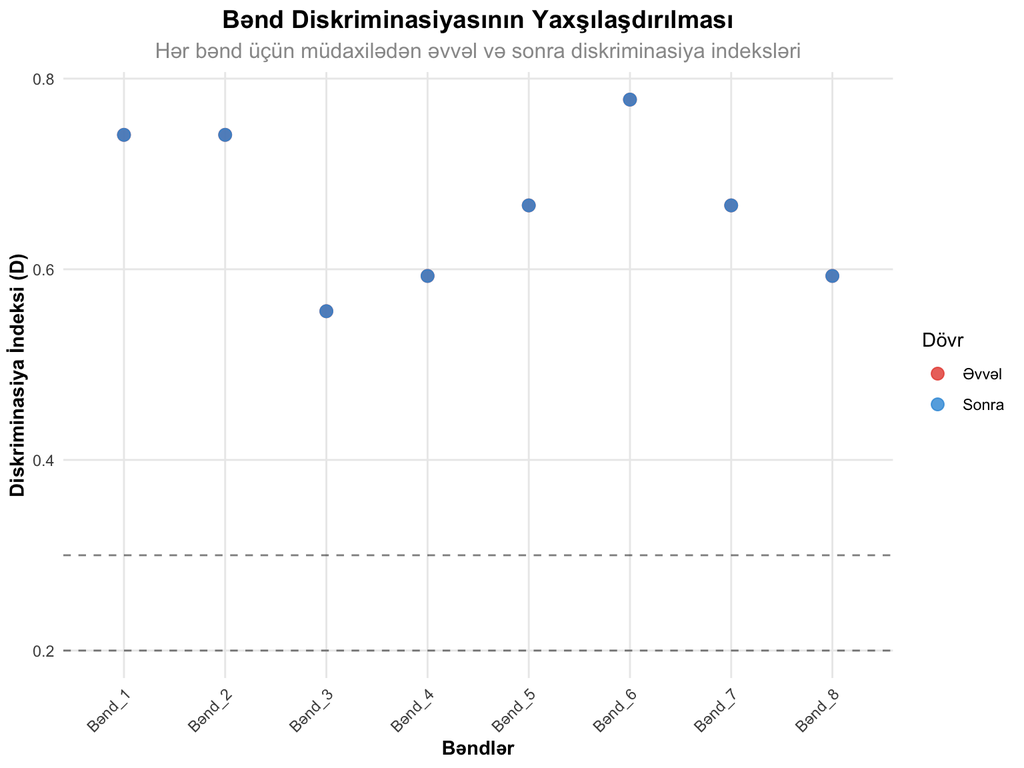

```r
# Yaxşılaşmanın vizuallaşdırılması
improvement_visual <- comparison_results %>%
  select(Bənd, Əvvəl_D, Sonra_D) %>%
  pivot_longer(cols = c(Əvvəl_D, Sonra_D), names_to = "Dövr", values_to = "Diskriminasiya") %>%
  mutate(Dövr = recode(Dövr, "Əvvəl_D" = "Əvvəl", "Sonra_D" = "Sonra"))

ggplot(improvement_visual, aes(x = Bənd, y = Diskriminasiya, color = Dövr, group = Bənd)) +
  geom_line(color = "gray70", size = 1) +
  geom_point(size = 3, alpha = 0.8) +
  scale_color_manual(values = c("Əvvəl" = colors_basic[2], "Sonra" = colors_basic[1])) +
  geom_hline(yintercept = c(0.20, 0.30), linetype = "dashed", alpha = 0.5) +
  labs(title = "Bənd Diskriminasiyasının Yaxşılaşdırılması",
       subtitle = "Hər bənd üçün müdaxilədən əvvəl və sonra diskriminasiya indeksləri",
       x = "Bəndlər", y = "Diskriminasiya İndeksi (D)", color = "Dövr") +
  theme_clean() +
  theme(axis.text.x = element_text(angle = 45, hjust = 1))
```

```r
# Ümumi yaxşılaşmanın statistikası
overall_improvement <- data.frame(
  Metrik = c("Orta Diskriminasiya", "Yaxşı Bənd Sayı (D ≥ 0.30)",
             "Zəif Bənd Sayı (D < 0.20)", "Test Etibarlılığı"),
  Əvvəl = c(
    round(mean(full_analysis$item_analysis$D), 3),
    sum(full_analysis$item_analysis$D >= 0.30),
    sum(full_analysis$item_analysis$D < 0.20),
    round(full_analysis$test_statistics$reliability_alpha, 3)
  ),
  Sonra = c(
    round(mean(improved_analysis$item_analysis$D), 3),
    sum(improved_analysis$item_analysis$D >= 0.30),
    sum(improved_analysis$item_analysis$D < 0.20),
    round(improved_analysis$test_statistics$reliability_alpha, 3)
  ),
  Dəyişiklik = c(
    round(mean(improved_analysis$item_analysis$D) - mean(full_analysis$item_analysis$D), 3),
    sum(improved_analysis$item_analysis$D >= 0.30) - sum(full_analysis$item_analysis$D >= 0.30),
    sum(improved_analysis$item_analysis$D < 0.20) - sum(full_analysis$item_analysis$D < 0.20),
    round(improved_analysis$test_statistics$reliability_alpha -
          full_analysis$test_statistics$reliability_alpha, 3)
  )
)

kable(overall_improvement, caption = "Test Səviyyəsində Ümumi Yaxşılaşdırma Nəticələri")
```

Test Səviyyəsində Ümumi Yaxşılaşdırma Nəticələri

| Metrik | Əvvəl | Sonra | Dəyişiklik |
| --- | --- | --- | --- |
| Orta Diskriminasiya | 0.667 | 0.667 | 0 |
| Yaxşı Bənd Sayı (D ≥ 0.30) | 8.000 | 8.000 | 0 |
| Zəif Bənd Sayı (D < 0.20) | 0.000 | 0.000 | 0 |
| Test Etibarlılığı | 0.658 | 0.658 | 0 |

# 8 Dərsin Xülasəsi

## 8.1 Əsas Nəticələr

**Diskriminasiya İndeksinin Mahiyyəti:** - ✓ **D = pₕ - pₗ** - yüksək və aşağı qruplar arasında fərq - ✓ **-1.0 ≤ D ≤ +1.0** - pozitiv dəyərlər yaxşı diskriminasiya göstərir - ✓ **D ≥ 0.30** - yaxşı bənd, **D < 0.20** - zəif bənd

**Korrelyasiya Növləri:** - ✓ **Point-biserial (rpb)** - ikili və davamlı dəyişən arasında - ✓ **Biserial (rb)** - əsas davamlı dəyişənin ikili kateqoriyaya bölünməsi - ✓ **Corrected item-total** - bənd inflasiyasının aradan qaldırılması

**Praktik Tətbiqlər:** - ✓ %27 metodunun tətbiqi və analizi - ✓ R-da avtomatik diskriminasiya hesablamaları - ✓ Bənd yaxşılaşdırma strategiyalarının işlənməsi

# 9 Ev Tapşırığı

## 9.1 Tapşırıq 1: Nəzəri Hissə (30 xal)

1. **D = pₕ - pₗ formulasının nəzəri əsasları** nədir? Niyə %27 metodu standart sayılır? (250 söz)
2. **Point-biserial və biserial korrelyasiya** arasındakı fərqləri izah edin. Hansı hallarda hansını istifadə edərik? (300 söz)
3. **Neqativ diskriminasiya problemi** nədir və hansı səbəblərdən yaranır? Həll yollarını təfərrüatı ilə izah edin. (250 söz)

## 9.2 Tapşırıq 2: R Praktik Analizi (40 xal)

```r
# Diskriminasiya analizi tapşırığı
set.seed(sizin_tələbə_nömrəniz)

# Verilmiş test məlumatları (12 bənd, 60 tələbə)
n_students <- 60
n_items <- 12

# Müxtəlif diskriminasiya səviyyələri ilə test yaradın
target_discriminations <- c(0.45, 0.35, 0.25, 0.15, 0.05, -0.10,
                           0.40, 0.30, 0.20, 0.10, 0.50, 0.18)

test_responses <- matrix(NA, nrow = n_students, ncol = n_items)
colnames(test_responses) <- paste0("Bənd_", 1:n_items)

# Hər bənd üçün cavabları simulyasiya edin (IRT 2PL modeli)
student_abilities <- rnorm(n_students, 0, 1)

for(i in 1:n_items) {
  item_difficulty <- runif(1, -0.5, 0.5)
  item_discrimination <- target_discriminations[i]

  for(j in 1:n_students) {
    prob <- 1 / (1 + exp(-(item_discrimination *
                         (student_abilities[j] - item_difficulty))))
    test_responses[j, i] <- rbinom(1, 1, prob)
  }
}

# TAPŞİRIQLAR:
# 1. Hər bənd üçün %27 metodu ilə diskriminasiya indeksini hesablayın
# 2. Point-biserial korrelyasiyalarını hesablayın
# 3. Biserial korrelyasiyalarını hesablayın
# 4. Corrected item-total korrelyasiyalarını hesablayın
# 5. Hər bənd üçün keyfiyyət qiyməti verin

# CAVABLARINIZI BU FORMATDA VERİN:
discrimination_results <- data.frame(
  Bənd = paste0("Bənd_", 1:n_items),
  Üst_Qrup_p = , # Doldurun
  Alt_Qrup_p = , # Doldurun
  Diskriminasiya_D = , # Doldurun
  Point_Biserial_rpb = , # Doldurun
  Biserial_rb = , # Doldurun
  Corrected_r = , # Doldurun
  Keyfiyyət_Qiyməti = # Doldurun ("Əla"/"Yaxşı"/"Orta"/"Zəif"/"Neqativ")
)

# ƏLAVƏ HESABLAMALAR:
print("Test statistikaları:")
print(paste("Orta diskriminasiya:", ))
print(paste("Yaxşı bənd sayı (D ≥ 0.30):", ))
print(paste("Zəif bənd sayı (D < 0.20):", ))
print(paste("Cronbach Alpha:", ))

# BONUS: Zəif diskriminasiyalı bəndlər üçün yaxşılaşdırma planı hazırlayın
```

## 9.3 Tapşırıq 3: Bənd Yaxşılaşdırma Strategiyası (30 xal)

Aşağıdakı üç problemli bənd üçün təfərrüatlı yaxşılaşdırma strategiyası hazırlayın:

**Bənd X:** D = -0.15, p = 0.65 (neqativ diskriminasiya)  
**Bənd Y:** D = 0.08, p = 0.45 (zəif diskriminasiya)  
**Bənd Z:** D = 0.18, p = 0.85 (orta diskriminasiya, çox asan)

Hər bənd üçün aşağıdakıları təmin edin:

1. **Problem diaqnozu** (problemi yaradan amillərin təhlili - 150 söz)
2. **Konkret yaxşılaşdırma addımları** (5-7 addım, hər addım üçün 50 söz)
3. **Gözlənilən nəticələr** (yaxşılaşdırmadan sonra D və p dəyərləri - 100 söz)
4. **Uğur meyarları** (yaxşılaşdırmanın necə ölçüləcəyi - 100 söz)

# 10 Növbəti Dərslərə Hazırlıq

## 10.1 Dərs 13: “Bənd-Ümumi Test Korrelyasiyası”

Növbəti dərsdə öyrənəcəklər:

- ✓ Item-total korrelyasiyasının hesablanması və interpretasiyası
- ✓ Corrected item-total correlation əhəmiyyəti
- ✓ Alpha-if-item-deleted analizi
- ✓ Bənd seçimi və test qısaldılması strategiyaları

## 10.2 Dərs 14: “Distraktor Analizi”

Sonrakı mövzular:

- ✓ Distraktor effektivliyinin ölçülməsi
- ✓ Qeyri-funksional distractorların təyini
- ✓ Multiple-choice bəndlərin optimallaşdırılması
- ✓ Response pattern analizi

# 11 Əlavə Tədqiqat Materialları

## 11.1 Əsas Ədəbiyyat

**Məcburi oxu:** - Allen, M.J., & Yen, W.M. (2002). *Introduction to Measurement Theory*. Fəsil 5: “Item Analysis” (səh. 118-145) - Crocker, L., & Algina, J. (2008). *Introduction to Classical and Modern Test Theory*. Fəsil 8: “Item Analysis”

**Tövsiyə olunan:** - Ebel, R.L., & Frisbie, D.A. (1991). *Essentials of Educational Measurement*. Fəsil 11: “Item Analysis” - Anastasi, A., & Urbina, S. (1997). *Psychological Testing*. Fəsil 7: “Item Analysis”

## 11.2 Online Resurslar

**R Paketləri və Alətləri:** - `psych::alpha()` - etibarlılıq və bənd analizi - `CTT::itemAnalysis()` - hərtərəfli bənd analizi - `ltm::descript()` - bənd təsviri statistikalar - [Online Discrimination Calculator](https://www.danielsoper.com/statcalc/calculator.aspx?id=93)

**Video Mənbələr:** - YouTube: “Item Discrimination Analysis in Educational Testing” - Coursera: “Psychometric Theory and Applications” - Khan Academy: “Test Development and Item Analysis”

# 12 Dərslər Arası Əlaqələr

## 12.1 Keçmiş Dərslər

**Dərs 11 → Dərs 12 Əlaqəsi:** - Çətinlik analizi → Diskriminasiya analizi - p indeksi → D indeksi - Bənd keyfiyyəti → Hərtərəfli qiymətləndirmə

## 12.2 Gələcək Dərslər

**Dərs 12 → Sonrakı Dərslər:** - Diskriminasiya analizi → Item-total korrelyasiya - Bənd keyfiyyəti → Bənd seçimi metodları - Yaxşılaşdırma strategiyaları → Distraktor analizi

# 13 Praktik Nümunə Həllər

## 13.1 Diskriminasiya Hesablama Nümunəsi

```r
# Nümunə diskriminasiya analizi həlli
example_data <- matrix(c(
  1, 0, 1, 1, 0,  # Tələbə 1 (yüksək qabiliyyət)
  1, 1, 1, 0, 1,  # Tələbə 2 (yüksək qabiliyyət)
  1, 1, 0, 1, 1,  # Tələbə 3 (yüksək qabiliyyət)
  0, 0, 1, 1, 0,  # Tələbə 4 (aşağı qabiliyyət)
  0, 1, 0, 0, 0,  # Tələbə 5 (aşağı qabiliyyət)
  0, 0, 0, 1, 0   # Tələbə 6 (aşağı qabiliyyət)
), nrow = 6, byrow = TRUE)

colnames(example_data) <- paste("Bənd", 1:5)

# Ümumi ballar
total_scores <- rowSums(example_data)
print("Ümumi ballar:", total_scores)

# Qruplar (üst və alt 50% - kiçik nümunə üçün)
upper_group <- which(total_scores >= median(total_scores))
lower_group <- which(total_scores < median(total_scores))

# Diskriminasiya hesablaması
for(i in 1:ncol(example_data)) {
  p_upper <- mean(example_data[upper_group, i])
  p_lower <- mean(example_data[lower_group, i])
  D <- p_upper - p_lower

  cat("Bənd", i, ":\n")
  cat("  Üst qrup p =", round(p_upper, 3), "\n")
  cat("  Alt qrup p =", round(p_lower, 3), "\n")
  cat("  Diskriminasiya D =", round(D, 3), "\n\n")
}
```

# 14 Tənqidi Düşünmə Sualları

## 14.1 Diskussiya Mövzuları

1. **Qrup Böyüklüyü Məsələsi:** %27 metodu optimal mıdır? %25 və ya %33 metodları nə vaxt üstün ola bilər?
2. **Diskriminasiya vs Çətinlik:** Çətin bənd həmişə yaxşı diskriminasiya göstərə bilməzmi? Bu qarşılıqlı təsir necə izah olunur?
3. **Neqativ Diskriminasiya Paradoksu:** Bəzən neqativ diskriminasiya test konstruksiyasının bir hissəsi ola bilərmi?
4. **Korrelyasiya Seçimi Dilemması:** Point-biserial, biserial və ya corrected item-total - hansını seçməlirik və nə vaxt?

# 15 Qiymətləndirmə Meyarları

## 15.1 Ev Tapşırığı Rubrikası

```r
# Diskriminasiya analizi rubrikası
discrimination_rubric <- data.frame(
  Komponent = c("Nəzəri Anlayış (30)", "R Praktik Analiz (40)", "Yaxşılaşdırma Strategiyası (30)"),
  Əla_90_100 = c("Formul və metodları tam başa düşür", "Mükəmməl kod və nəticələr",
                  "Yaradıcı və ətraflı strategiya"),
  Yaxşı_80_89 = c("Əsas konseptləri bilir", "Kiçik kod səhvləri",
                   "Yaxşı struktur və təkliflər"),
  Kafi_70_79 = c("Ümumi anlayış var", "Bəzi hesablama səhvləri",
                  "Əsas strategiya mövcud"),
  Zəif_60_69 = c("Çaşqın və natamam", "Kodda əsaslı problemlər",
                  "Səthə düşən təkliflər")
)

kable(discrimination_rubric, caption = "Diskriminasiya Analizi Dərsinin Rubrikası")
```

Diskriminasiya Analizi Dərsinin Rubrikası

| Komponent | Əla_90_100 | Yaxşı_80_89 | Kafi_70_79 | Zəif_60_69 |
| --- | --- | --- | --- | --- |
| Nəzəri Anlayış (30) | Formul və metodları tam başa düşür | Əsas konseptləri bilir | Ümumi anlayış var | Çaşqın və natamam |
| R Praktik Analiz (40) | Mükəmməl kod və nəticələr | Kiçik kod səhvləri | Bəzi hesablama səhvləri | Kodda əsaslı problemlər |
| Yaxşılaşdırma Strategiyası (30) | Yaradıcı və ətraflı strategiya | Yaxşı struktur və təkliflər | Əsas strategiya mövcud | Səthə düşən təkliflər |

## 15.2 Təbriklər!

Bənd diskriminasiya analizini uğurla başa vurdunuz! İndi D indeksini hesablaya və bənd keyfiyyətini qiymətləndirə bilirsiniz.

**Növbəti dərsdə item-total korrelyasiya analizini öyrənəcəksiniz! 🔍**

*Bu dərs Allen və Yen (2002), Crocker & Algina (2008) və digər psixometrik mənbələrinə əsaslanır.*

**Son yenilənmə:** 2025-07-17 | **Versiya:** 1.0